# Traffic flows & bus prediction

Tom Elliott

[figure not shown]

PhD Talks Day 2019

# Overview

GPS positions

$\downarrow$

Travel times

$\downarrow$

Network state

$\downarrow$

Arrival time distributions

$\downarrow$

ETAs

# Part One GPS positions$\downarrow$travel times

## Real-time vehicle locations

- Auckland Transport provides API for real-time data
- **Vehicle locations**: GPS coordinates of buses/trains
- **Trip updates**: arrival/departure times at bus stops
- Over 1000 buses operating at peak
- Target: ETAs updated every 30 seconds

## Vehicle state

- Unknown vehicle state $\boldsymbol{x}_k = [x_k, \dot x_k]^\top$, at time $t_k$
  - $x_k$: distance travelled along route, meters
  - $\dot x_k$: speed, meters per second
- Observable state $\boldsymbol{y}_k = h(\boldsymbol{x}_k) + \boldsymbol{\epsilon}_k$

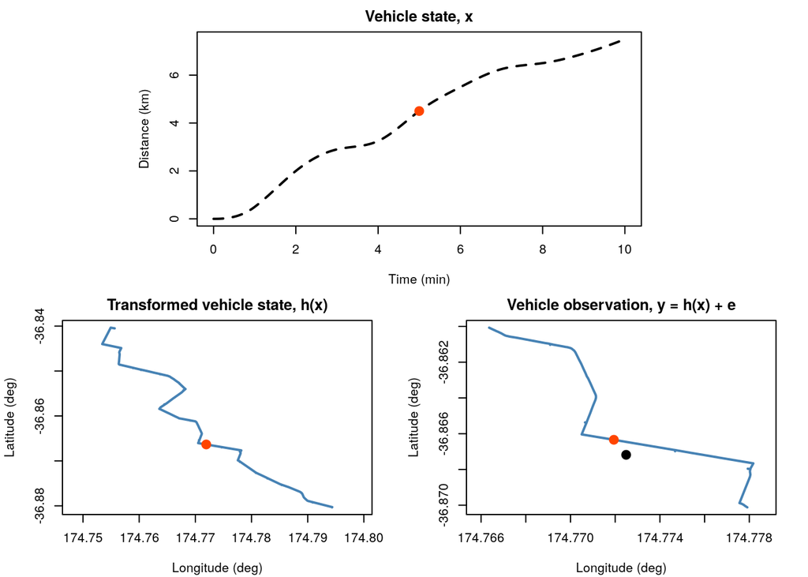

## Particle filter

- Approximate vehicle state using sample of $N$ particles

  $$p(\boldsymbol{x}_{k-1} | \boldsymbol{y}_{1:k-1}) \approx
  \sum_{i=1}^N \boldsymbol{w}_{k-1}^{(i)} \delta_{\boldsymbol{x}_{k-1}^{(i)}}(\boldsymbol{x}_{k-1})$$
  - $\boldsymbol{x}_{k-1}^{(i)}$: state (distance, velocity) of particle $i$
  - $\boldsymbol{w}_{k-1}^{(i)}$: weight of particle $i$
  - $\delta_{x^{(i)}}(x)$: Dirac measure

## Particle filter ii

- **Vehicle transition function**, $f$
  - Acceleration/deceleration
  - Bus stop behaviour
  - Traffic lights, etc.

    $$\boldsymbol{x}_k^{(i)} = f(\boldsymbol{x}_{k-1}^{(i)}, \sigma_x^2, ...)$$
- Predicts new state *before* observing latest position

  $$p(\boldsymbol{x}_{k} | \boldsymbol{x}_{k-1}) \approx
  \sum_{i=1}^N \boldsymbol{w}_{k-1}^{(i)} \delta_{\boldsymbol{x}_k^{(i)}}(\boldsymbol{x}_{k})$$

## Particle filter iii

- Update using likelihood function
- Distance (squared) between particle and observation
- Measurement error $\epsilon^2$ = GPS error (meters)

  $$d\left(\boldsymbol{y}_k, h(\boldsymbol{x}_k^{(i)})\right)^2 \sim Exp\left(\frac{1}{2\epsilon^2}\right)$$

## Particle filter iv

- Update vehicle state by reweighting particles

$$\boldsymbol{w}_k^{(i)} = \frac{\boldsymbol{w}_{k-1}^{(i)} p(\boldsymbol{y}_k | \boldsymbol{x}_k^{(i)})}{\sum_{j=1}^N \boldsymbol{w}_{k-1}^{(j)} p(\boldsymbol{y}_k | \boldsymbol{x}_k^{(j)})}$$

$$p(\boldsymbol{x}_k | \boldsymbol{y}_{1:k}) \approx
\sum_{i=1}^N \boldsymbol{w}_{k}^{(i)} \delta_{\boldsymbol{x}_k^{(i)}}(\boldsymbol{x}_{k})$$

## Estimating travel times

- Estimated once vehicle has completed each segment
  - $T_j^{(i)}$: travel time particle $i$, segment $j$
  - Computed in transition function
- Posterior estimate of travel time

  $$p(T_j | \boldsymbol{y}_{1:k}) \approx
  \sum_{i=1}^N \boldsymbol{w}_{k}^{(i)} \delta_{T_j^{(i)}}(T_{j})$$

# Part Two Travel times$\downarrow$Network state

## Transit road network

- **road network** consists of all $M$ **road segments**
- estimate of traffic flows (as travel times)
- **combines data from different routes**

## Network state

- travel time (seconds) of buses along roads at time $t_c$

  $$\Theta_c =
  [
  \theta_{1c}, \theta_{2c}, \cdots, \theta_{Mc}
  ]^\top$$
- summarize by mean and variance

  $$\hat\Theta_{c|c} = \mathrm{E}(\Theta_c | T_{1:c})$$
  $$\Sigma_{c|c} = \mathrm{Var}(\Theta_c | T_{1:c})$$

## Information filter

- alternate form of Kalman filter
- replace mean and variance by
  - **information matrix**
    $$\mathbf{P}_{c-1|c-1} = \Sigma_{c-1|c-1}^{-1}$$
  - **information vector**
    $$\boldsymbol{p}_{c-1|c-1} = \Sigma_{c-1|c-1}^{-1}\hat\Theta_{c-1|c-1}$$
- **easy handling of multiple observations**
  - buses tend to clump together

## Information filter ii

- predict next state
  - travel times constant over short (30 sec) intervals
  - system noise $\rho^2$ (s/s)

    $$\begin{split}
    \hat\Theta_{c|c-1} &= \hat\Theta_{c-1|c-1} \\
    \Sigma_{c|c-1} &= \Sigma_{c-1|c-1} + \mathbf{I} \rho^2
    \end{split}$$
- update road segments independently
  - avoid inverting large matrices
  - not observing correlations

## Information filter iii

- $L_c^j$ buses completing segment $j$ at time $t_c$
- observation and measurement error for each

  $$\begin{split}
  z_c^{j\ell} &= \mathrm{E}(T_j^\ell | \boldsymbol{y}_{1:k}^\ell) \\
  R_c^{j\ell} &= \max\{\mathrm{Var}(T_j^\ell | \boldsymbol{y}_{1:k}^\ell), R_\text{min}\}
  \end{split}$$
- transform to information space

  $$\begin{split}
  {I}_c^{j\ell} &= ({R}_c^{j\ell})^{-1} \\
  {i}_c^{j\ell} &= ({R}_c^{j\ell})^{-1} {z}_c^{j\ell}
  \end{split}$$

## Information filter iv

- update state by adding information

  $$\begin{split}
  (\mathbf{P}_{c|c})_{jj}
  &= (\mathbf{P}_{c|c-1})_{jj} + \sum_\ell {I}_{c}^{j\ell} \\
  (\boldsymbol{p}_{c|c})_j &= (\boldsymbol{p}_{c|c-1})_j + \sum_\ell {i}_{c}^{j\ell}
  \end{split}$$
- back transform for state parameters

## Network state prediction

- use historical data to forecast (e.g., 10 mins ahead)
- include correlations between adjacent segments

# Part Three Network state$\downarrow$Arrival time distrutions

## Predicting arrival time

- when will the bus arrive at stop $m$ given
  - latest estimate of position/speed
  - current network state (traffic conditions)
- uncertainty from
  - position/speed estimate
  - traffic conditions now *and in the near future*
  - dwell time at stops (can be zero)
  - traffic lights, random traffic fluctuations, …

## Reprise the particle filter

- for each particle, run transition function $f'$
  - sample travel times from $\Theta_c$
  - continue to end of route
  - $A_m^{(i)}$: particle arrival time at stop $m$

$$p(A_m | \boldsymbol{x}_k, \Theta_c) \approx
\sum_{i=1}^N \boldsymbol{w}_{k}^{(i)} \delta_{A_{m}^{(i)}}(A_m)$$

## Maybe not …

- requires simulating $N \times M_\text{remaining}$ arrival times
- for upwards of 1000 buses at peak times
- every 30 seconds …

## (Work in progress)

- use particle filter to estimate next $M'$ stops
- predict remaining travel time using normal theory
- allow uncertainty to converge to prior (historical data)

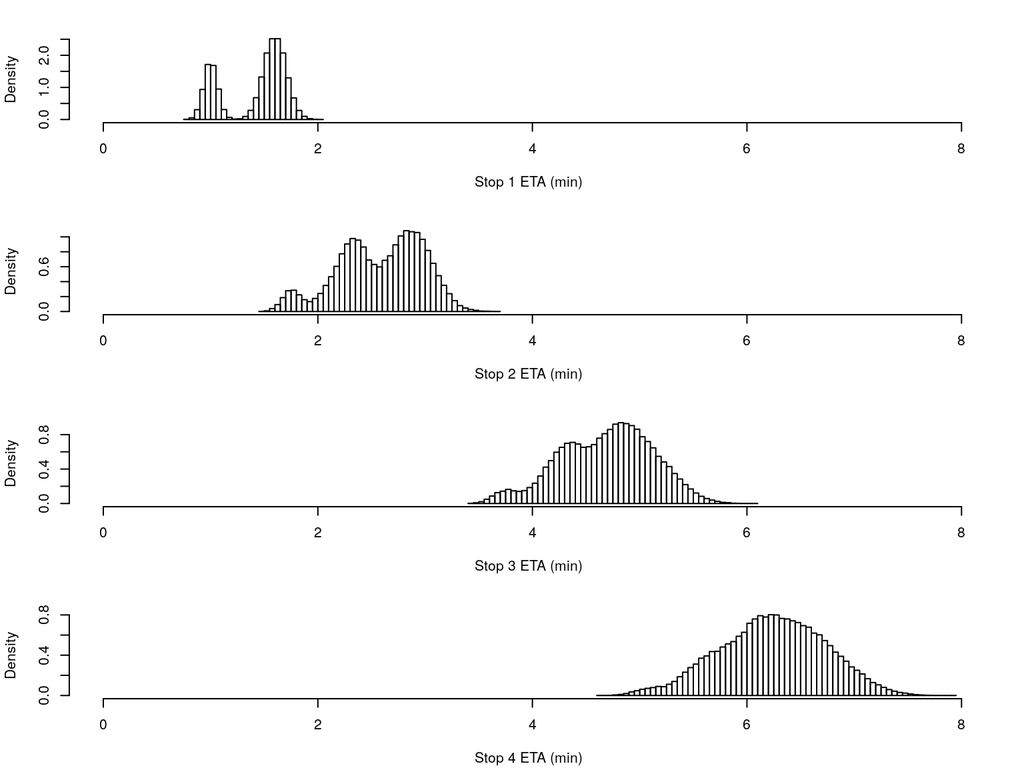

# Part Four Arrival time distrutions$\downarrow$ETAs

## Arrival time distribution

- we have a distribution

  $$p(A_j | \boldsymbol{x}_k, \Theta_c)$$
- need to summarize it for the general public

## Point estimates

- expected
- easy to communicate
- infrastrature exists (real-time boards, etc)

## Point estimates ii

- assumes ETA is exact (it’s not)
- underestimate = frustration, hard to plan journey
- overestimate = shorter wait OR miss bus entirely

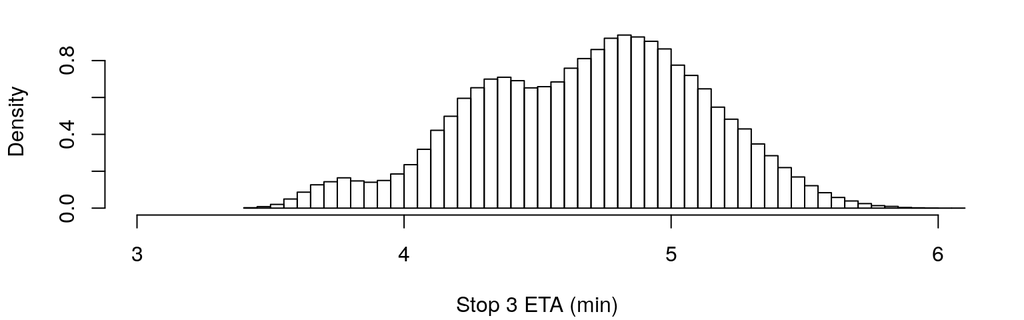

- mean? median? some quantile?
- minimise $p(A_j \notin [\hat A_j, \hat A_j+1)), A_j \in 0, 1, 2, \ldots$
- … stronger penalty on overestimation?

### Point estimates iii

- desirable that $A_j$ decreases with time
- Kalman filter on arrival times? at least for > 10 mins

### Prediction intervals

- unfamiliar to the general public
- allows uncertainty to be expressed
  - at least $\ell_j$ mins away, could be up to $u_j$ mins
- what values?
  - quantiles of predictive distribution?
  - min $p(A_j \notin [\ell_j, u_j])$ constrained by $(u_j - \ell_j)^2$

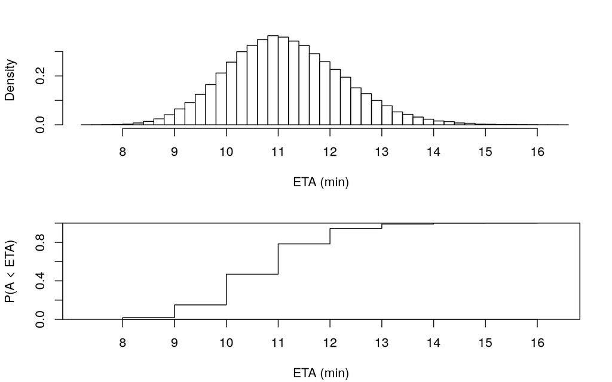

Probability (%) bus arrives within x mins

| 7 | 8 | 9 | 10 | 11 | 12 | 13 | 14 | 15 | 16 |
| --- | --- | --- | --- | --- | --- | --- | --- | --- | --- |
| 0.05 | 1.8 | 15 | 46.9 | 78.4 | 94.4 | 99 | 99.874 | 99.991 | 100 |

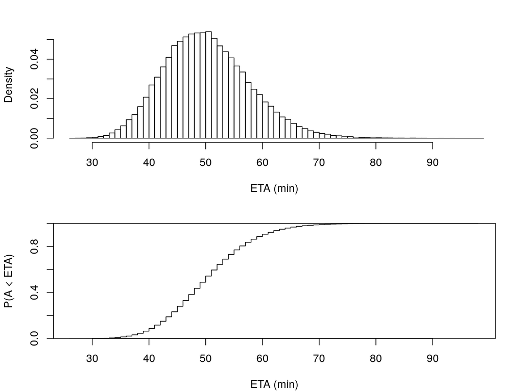